# crasch Tutorial 3 - A Full `crasch` Analysis

## `wm()`

### A wrapper for the `wrightMap()` function

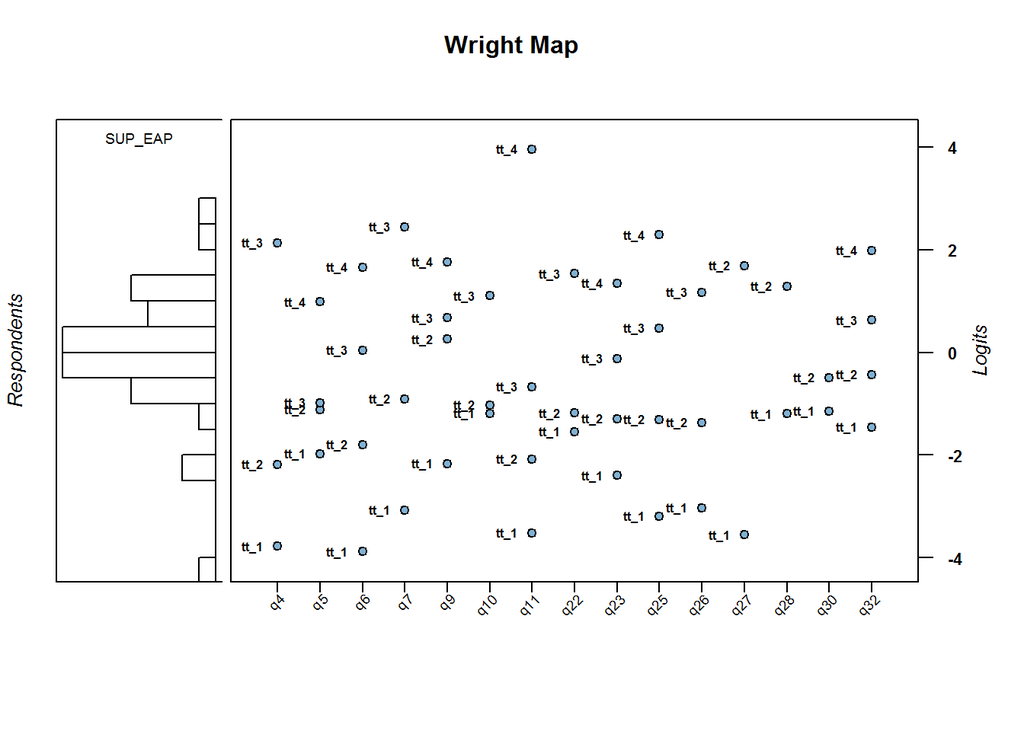

```r
?wm
# The most relevant argument to change for our purposes is:
  #    byCat

wm(SUPanalysis) # organized in item order
```

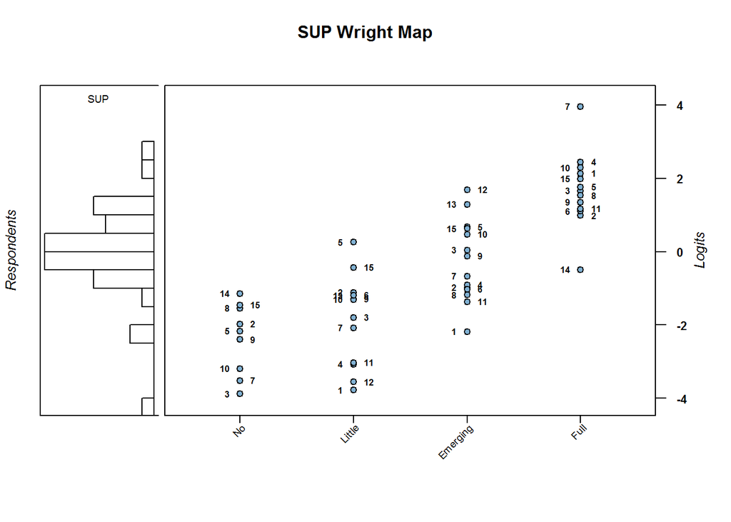

```r
wm(SUPanalysis, byCat = TRUE) # organized in construct category order
```

You can use `palette`, `writeout`, `imageType`, and `fileSuffix` as above.

If you want to customize the output further, see the `wrightMap()` function documentation. The function provided in this package is merely a wrapper.

```r
?wrightMap
```

## `pers.hist()`

### Produce a histogram of the estimated person locations with a normal curve overlaid

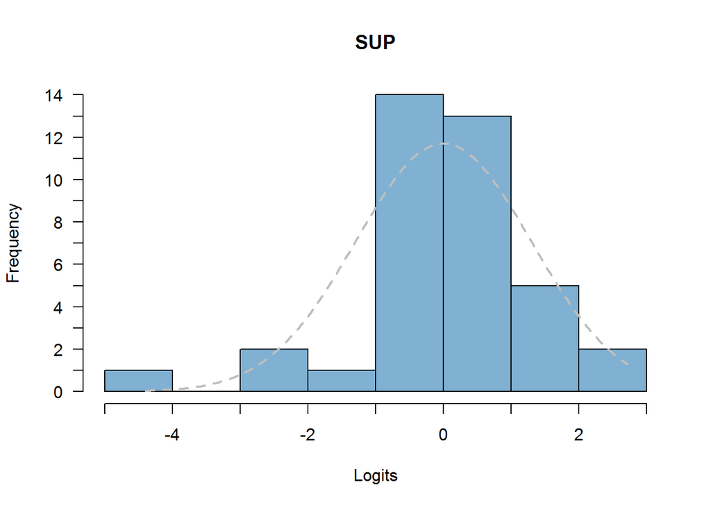

```r
?pers.hist

pers.hist(SUPanalysis)
```

You can change the colors and the write options as above.

```r
pers.hist(SUPanalysis, palette = "Spectral")
# You can also specify any 2 R colors in a vector
  pers.hist(SUPanalysis, palette = c("red", "darkred"))
# Graphical output omitted

# Graphic options
pers.hist(SUPanalysis, writeout = TRUE, imageType = "png")
```

For a list of R color names: http://www.stat.columbia.edu/~tzheng/files/Rcolor.pdf

## `infit.MNSQ()`

### Produce a graphic of item fit statistics

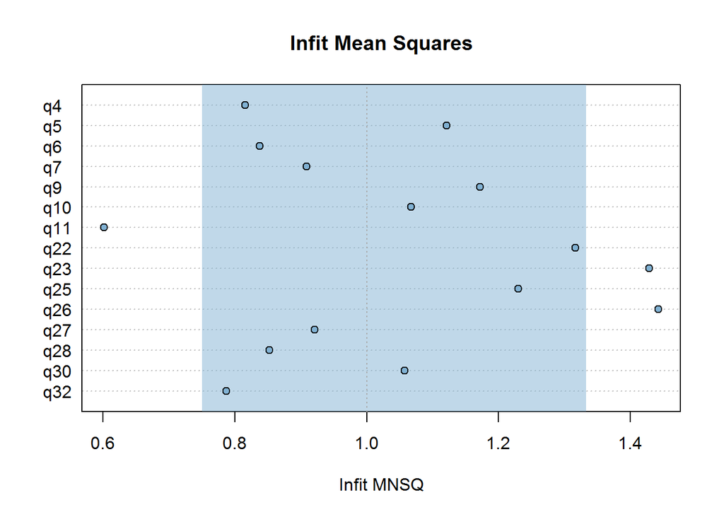

```r
?infit.MNSQ

# The most relevant arguments to change for our purposes are:
  #    itemOrder
  #    params

infit.MNSQ(SUPanalysis)
```

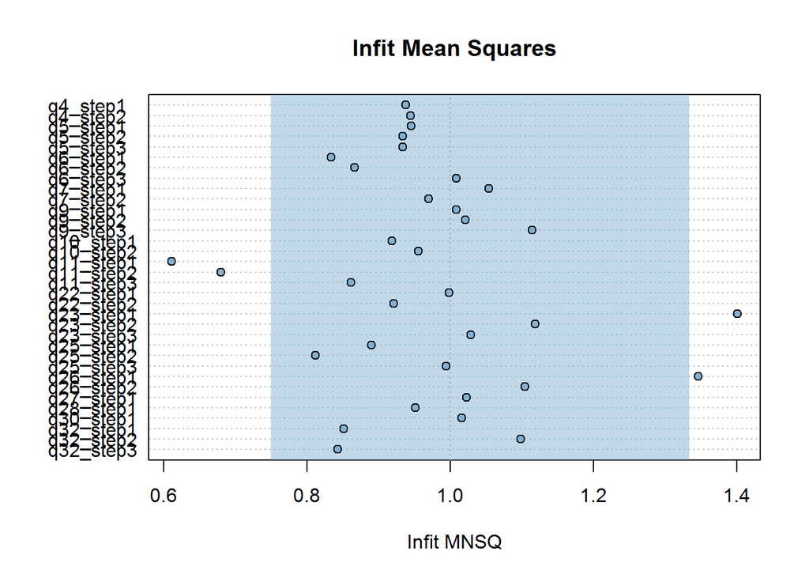

```r
# To plot the step fit instead of the overall item fit:
infit.MNSQ(SUPanalysis, params = "steps")
```

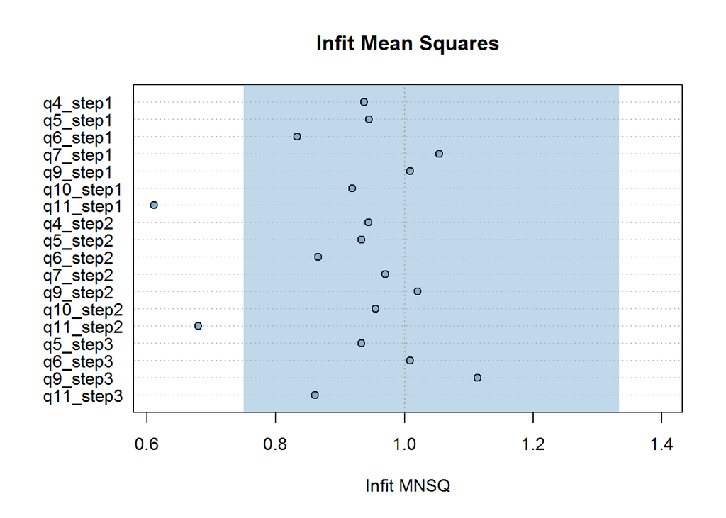

```r
# To restrict which items are plotted on each graph:
infit.MNSQ(SUPanalysis, itemOrder = c(1, 2, 3, 4, 5, 6, 7), params = "steps")
```

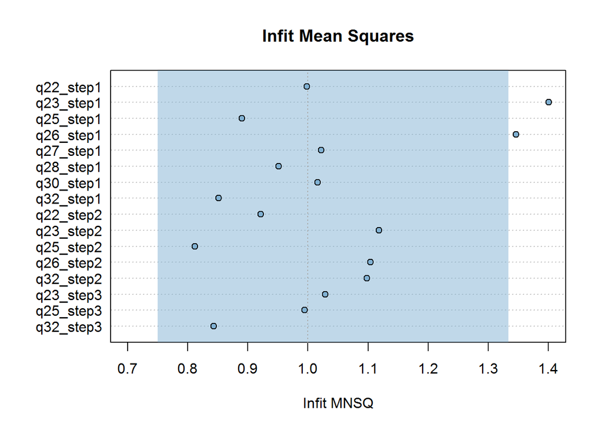

```r
infit.MNSQ(SUPanalysis, itemOrder = 8:15, params = "steps")
```

You can change the colors and the write options as above.

```r
infit.MNSQ(SUPanalysis, itemOrder = 8:15, palette = "Spectral")
# Graphical output omitted

infit.MNSQ(SUP_MLE, writeout = TRUE, fileSuffix = "MLE", imageType = "tiff")
```

## `KIDMAP()`

### Produce a KIDMAP graphic for a given respondent

```r
?KIDMAP
# For the KIDMAP function you must specify a respondent ID!
# Look at the list of your IDs:
row.names(SUPscores)
```

```
##  [1] "110" "111" "112" "113" "114" "115" "116" "117" "118" "119" "120"
## [12] "121" "122" "123" "124" "125" "126" "127" "128" "129" "130" "131"
## [23] "132" "133" "134" "135" "136" "137" "138" "139" "140" "141" "142"
## [34] "143" "144" "145" "146" "147"
```

```r
KIDMAP(SUPanalysis, 120)
```

```
## No output was written to file. If you wish to write to file, use writeout=TRUE.
```

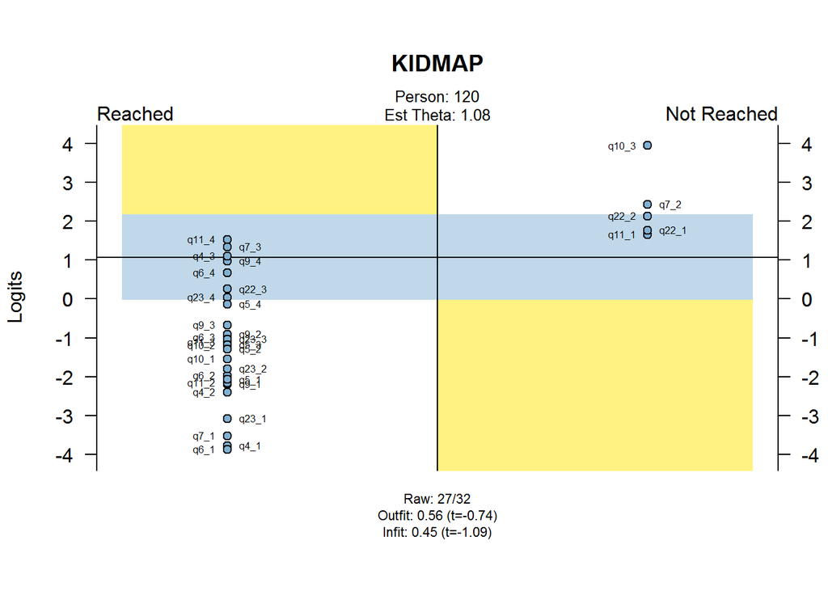

```r
# You can make multiple KIDMAPs at once if you like:
KIDMAP(SUPanalysis, c(119, 121, 126))
```

```
## No output was written to file. If you wish to write to file, use writeout=TRUE.
```

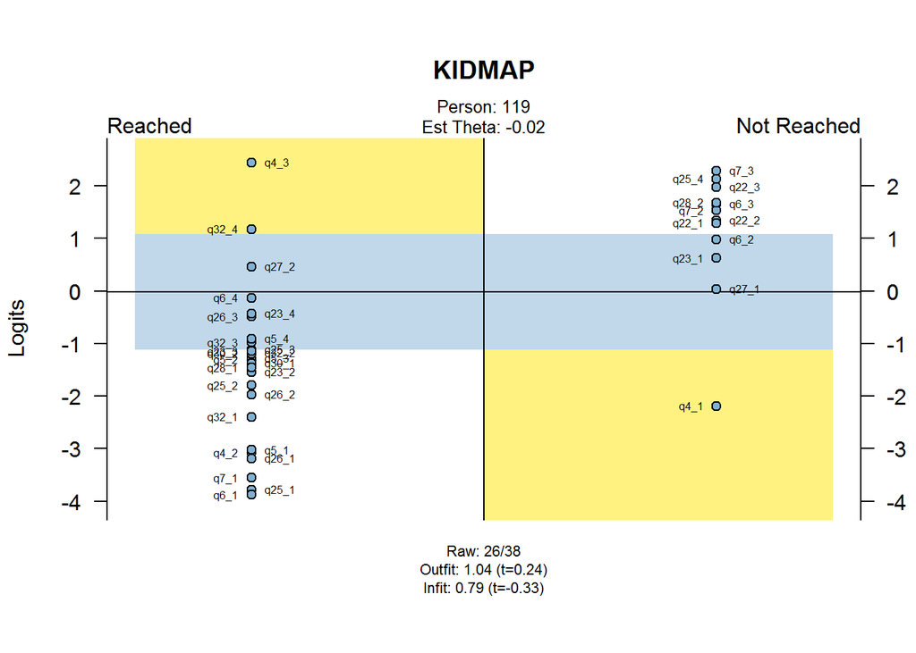

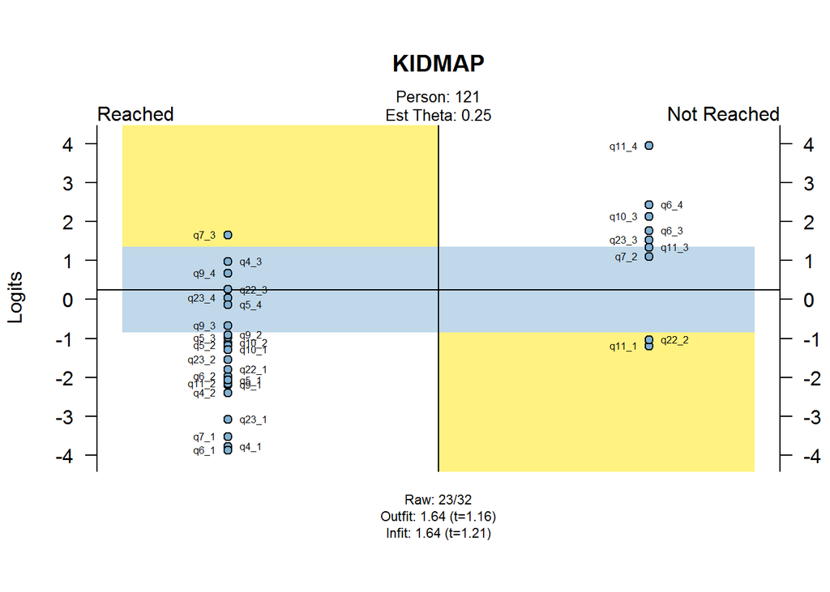

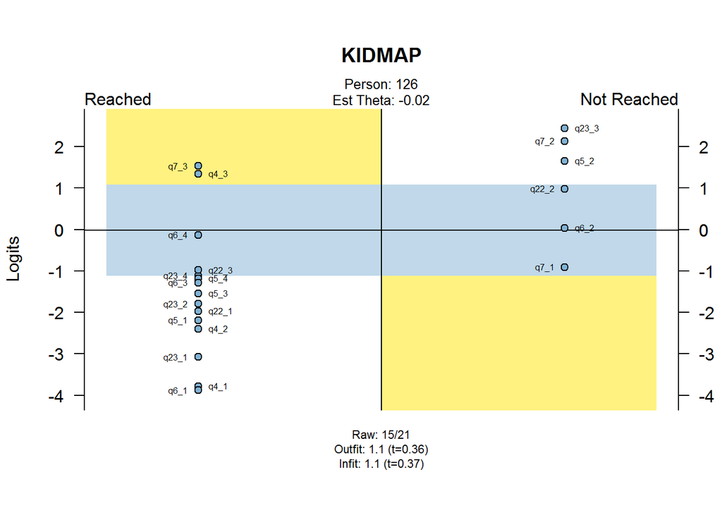

You can change the colors and the write options as above.

```r
KIDMAP(SUPanalysis, 120, palette = "Spectral")
# You can also specify any 3 R colors in a vector
  KIDMAP(SUPanalysis, 147, palette = c("darkred", "red", "black"))
# Graphical output omitted

# Graphic options
KIDMAP(SUPanalysis, 120, palette = "PuBu", writeout = TRUE, imageType = "png")
KIDMAP(SUP_MLE, 120, palette = "PuBu", writeout = TRUE, imageType = "png",
       fileSuffix = "MLE")
```

## `item.analysis()`

### Produce by item and by step tables

```r
?item.analysis

item.analysis(SUPanalysis)

item.analysis(SUPanalysis, writeout = TRUE)
```

Truncated output:

```
##     Item_no Construct Count Missing   Estimate    SE_est    outfit
## q4        1       SUP    38       0 -1.9177950 0.2880459 0.8294792
## q5        2       SUP    37       1 -1.0465970 0.2021277 0.8682833
## q6        3       SUP    38       0 -1.3290784 0.2017615 0.7796817
## q7        4       SUP    38       0 -0.7740587 0.2651591 0.8982915
## q9        5       SUP    30       8  0.1850896 0.2098627 1.1043334
## q10       6       SUP    31       7 -0.5273568 0.2413000 1.0437959
##       outfit_t  outfit_p     infit    infit_t   infit_p
## q4  -0.6530822 0.1284258 0.8161102 -0.7867048 0.1078637
## q5  -0.2696806 0.1968515 1.1214520  0.4322537 0.1663893
## q6  -0.8377364 0.1005447 0.8381170 -0.7746047 0.1096433
## q7  -0.3869960 0.1746898 0.9085317 -0.3466725 0.1822093
## q9   0.4035438 0.1716370 1.1721810  0.6853505 0.1232807
## q10  0.2541676 0.1998415 1.0676138  0.2980298 0.1914201
```

```
##   Item Construct      Cat Count Score   Estimate    SE_est Threshold
## 1   q4       SUP     Anti     1     0         NA        NA        NA
## 2   q4       SUP   Little     3     1 -1.6364993 0.3583117 -3.780061
## 3   q4       SUP Emerging    17     2 -0.4862957 0.3463497 -2.189849
## 4   q4       SUP     Full    17     3  4.0405900        NA  2.133458
## 5   q5       SUP     Anti     3     0         NA        NA        NA
## 6   q5       SUP       No     3     1 -0.6457501 0.3605817 -1.971684
##   PtBiserial MeanPersLoc SD_PersLoc
## 1 -0.5296499  -4.3952112         NA
## 2 -0.4184557  -1.4655254  1.2554953
## 3 -0.0601707  -0.1429935  0.6136562
## 4  0.4576225   0.6627785  0.9248912
## 5 -0.4417630  -1.4157767  2.6222004
## 6 -0.5030683  -0.6025885  1.5225986
```

## `ICC.graph()`

### Produce graphics of the item (or category) characteristic curves

```r
?ICC.graph

ICC.graph(SUPanalysis) # produces a graph for each item
# Graphical output omitted
```

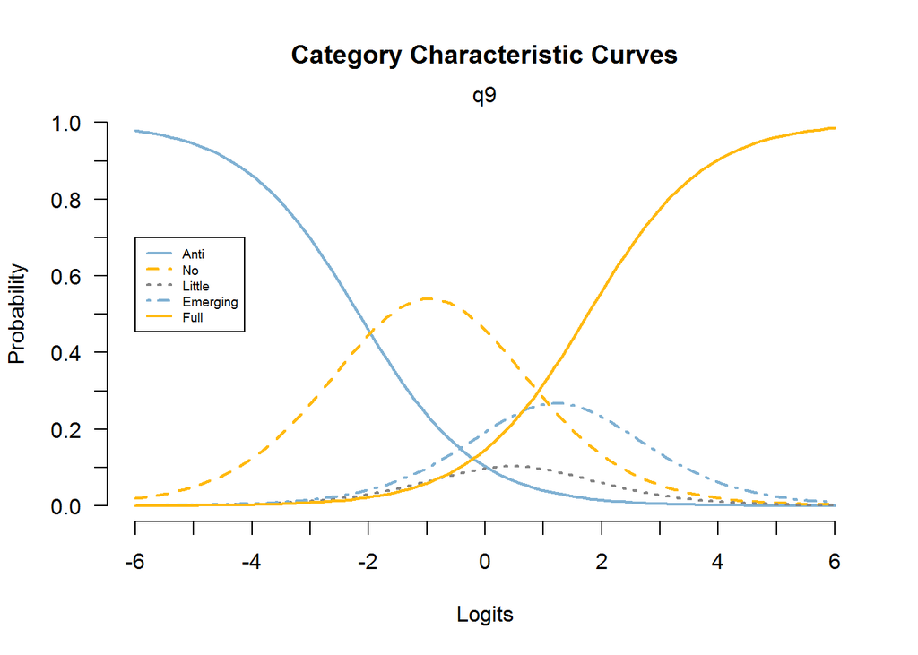

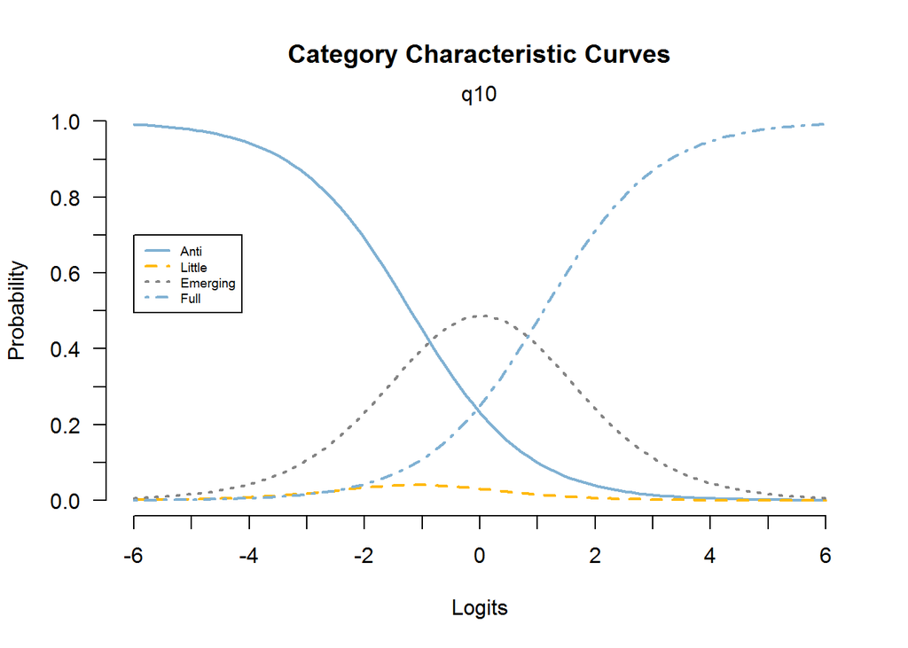

```r
# To selectively produce graphs use itemOrder
ICC.graph(SUPanalysis, itemOrder = c(5:6))
```

You can use `palette`, `writeout`, `imageType`, and `fileSuffix` as above.

## `CPC.graph()`

### Produce graphics of cumulative probability curves

```r
?CPC.graph

# The most relevant arguments to change for our purposes are:
  #    itemOrder
  #    observed
  #    minCell
  #    focusTheta

CPC.graph(SUPanalysis) # Note that a separate graph is produced for each item
# Graphical output omitted
```

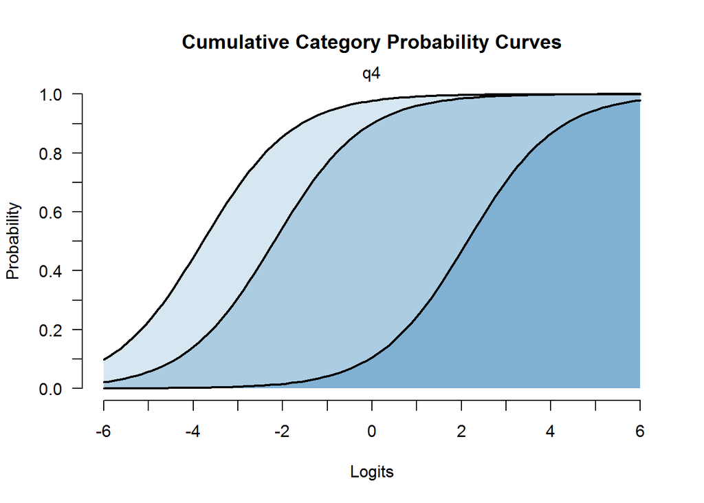

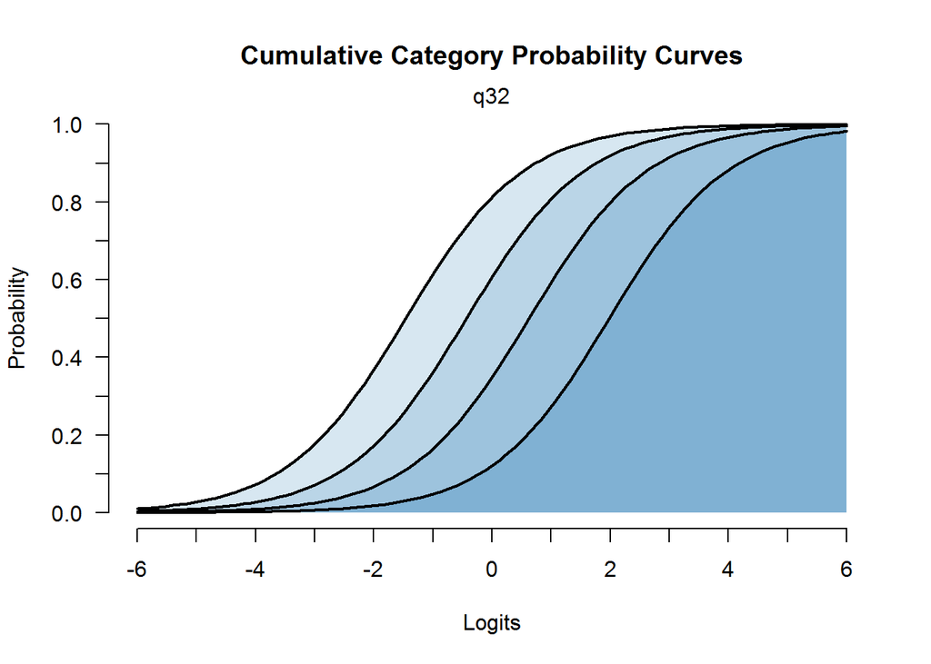

```r
# To selectively produce graphs use itemOrder
CPC.graph(SUPanalysis, itemOrder = c(1, 15))
```

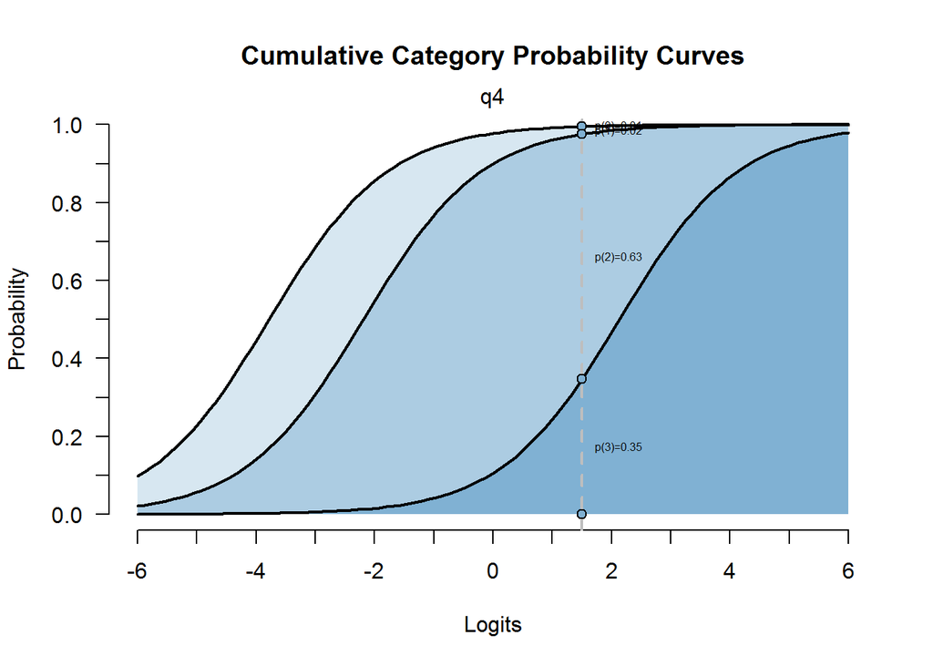

```r
# You can obtain category probabilities for specified theta values
#   You can specify a single value or a vector using c()
CPC.graph(SUPanalysis, itemOrder = 1, focusTheta = 1.5)
```

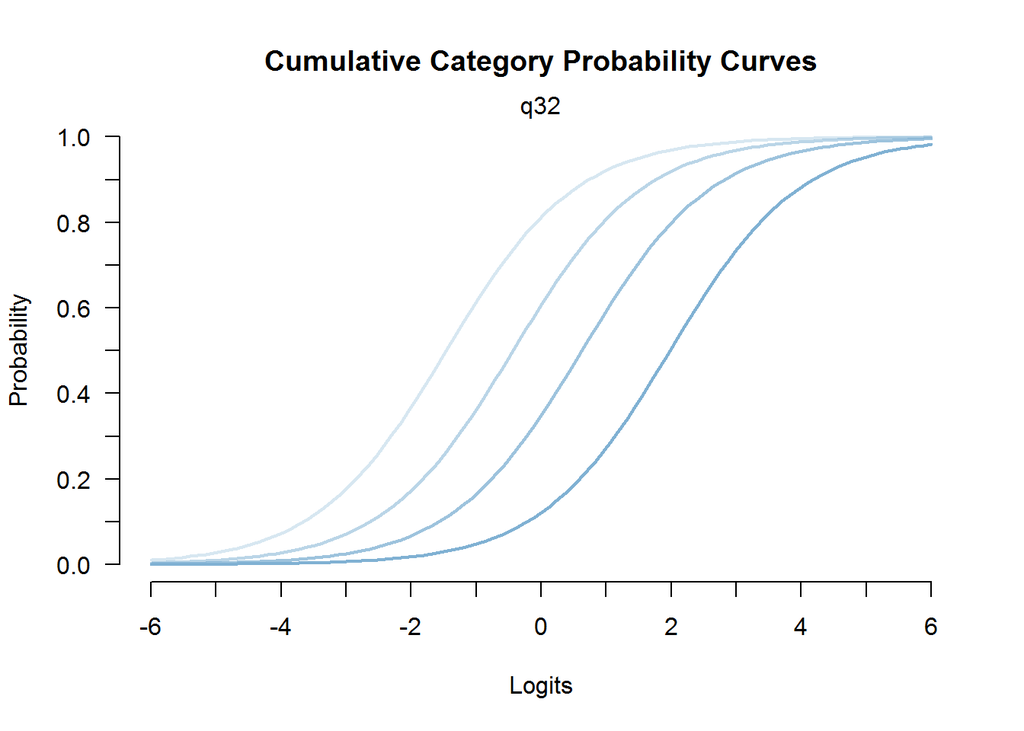

```r
# To plot your observed proportions, use observed and minCell
CPC.graph(SUPanalysis, itemOrder = 15, observed = TRUE)
```

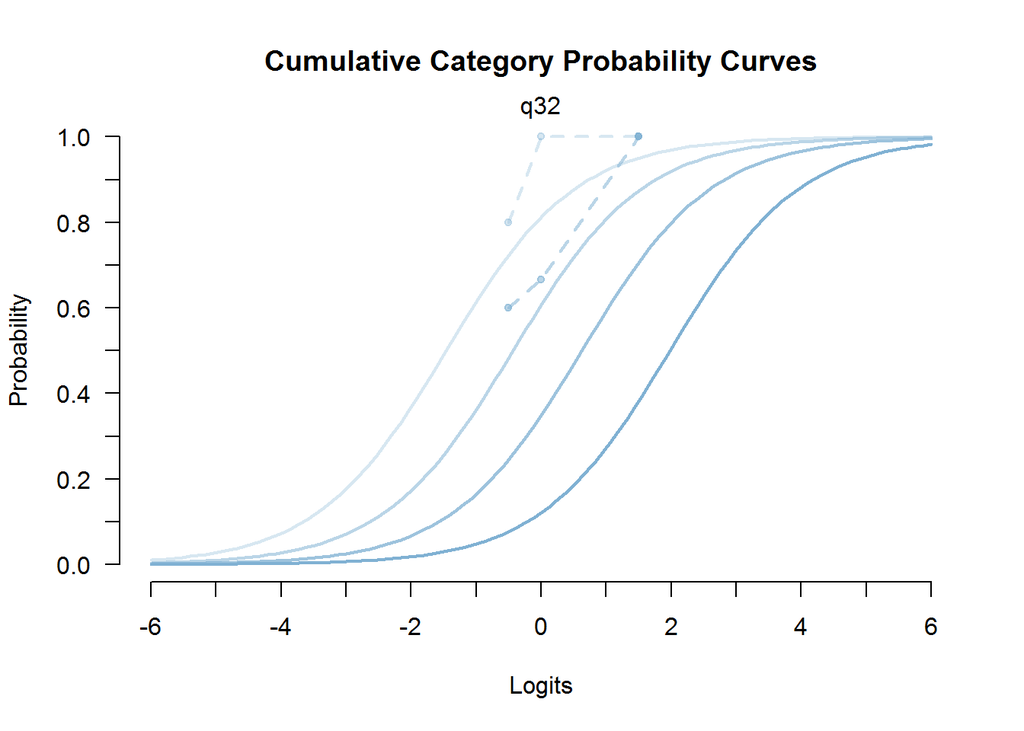

```r
CPC.graph(SUPanalysis, itemOrder = 15, observed = TRUE, minCell = 3)
```

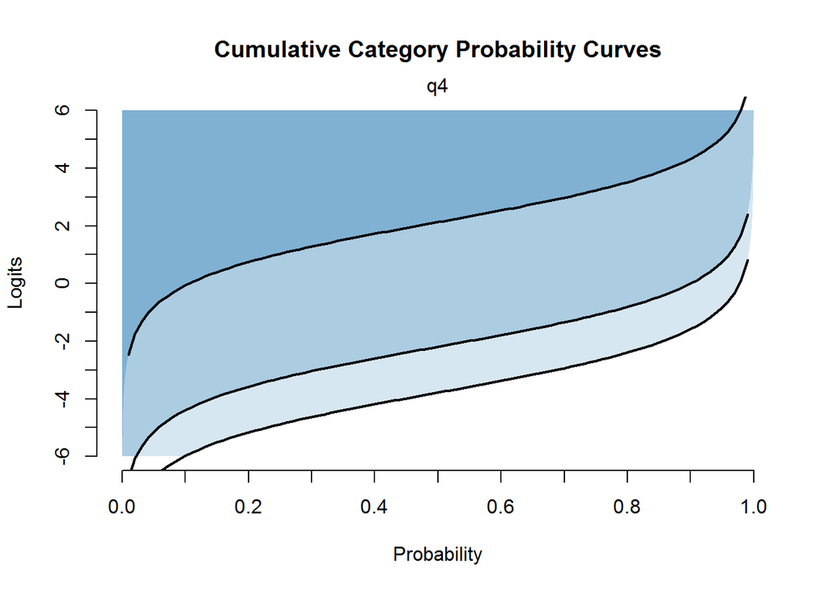

```r
# You can make "vertical" plots as is in the text using logitAxis = "y"
CPC.graph(SUPanalysis, itemOrder = 1, logitAxis = "y")
```

You can use `palette`, `writeout`, `imageType`, and `fileSuffix` as above.

## `info.graph()`

### Produce graphics of test and item information

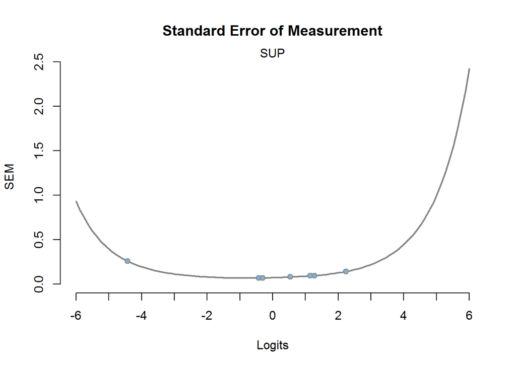

```r
?info.graph

# The most relevant arguments to change for our purposes are:
  #    type
  #    completeOnly

info.graph(SUPanalysis, type = "SEM")  # SEM is the default
```

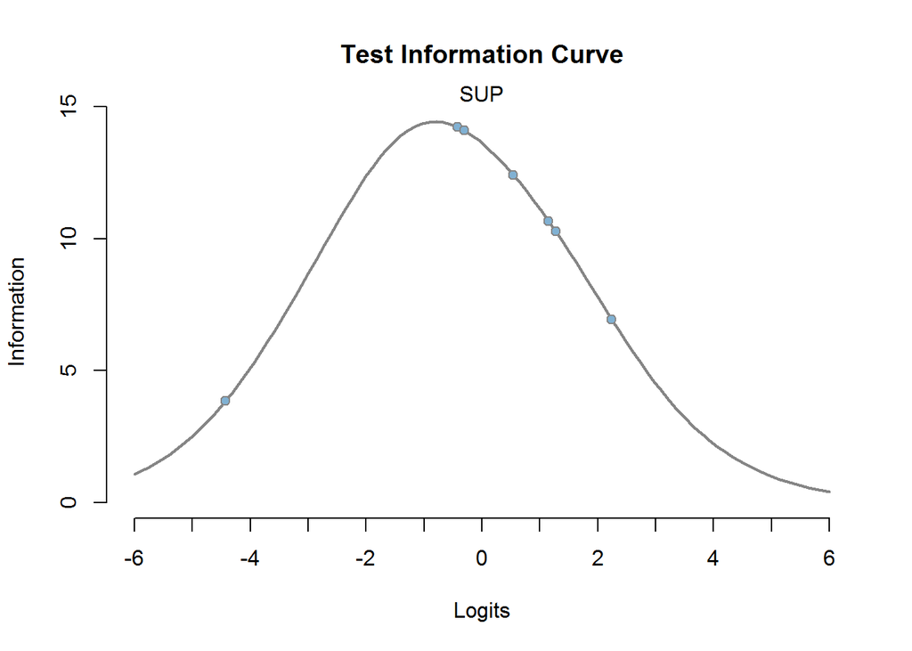

```r
info.graph(SUPanalysis, type = "TIC")  # produces one graph
```

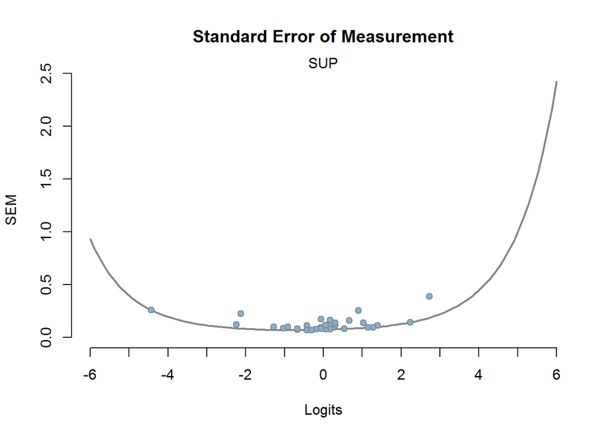

```r
# The default is to plot only observed values for COMPLETE data
#  You can also plot *all* observations
info.graph(SUPanalysis, type = "SEM", completeOnly = FALSE)
```

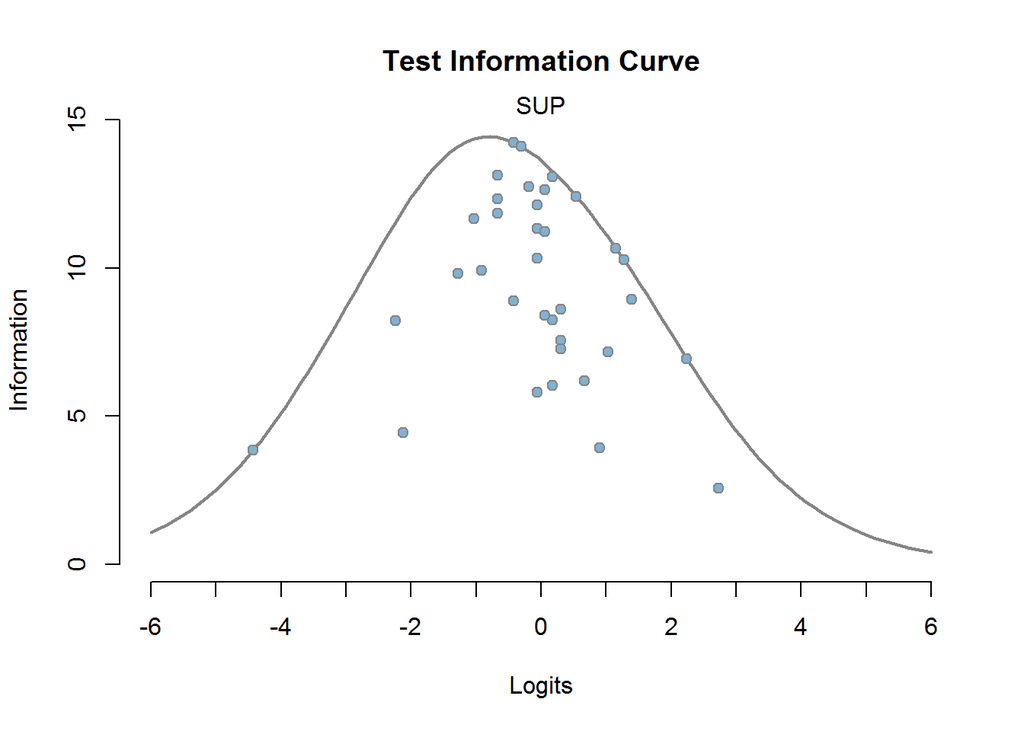

```r
info.graph(SUPanalysis, type = "TIC", completeOnly = FALSE)
```

```r
info.graph(SUPanalysis, type = "IIC")  # produces one graph for each item
# Graphical output omitted

# The plotted points are observed thetas.
```

You can use `palette`, `writeout`, `imageType`, and `fileSuffix` as above.

## `Split.halves()`

### Calculate the split halves reliability coefficient

```r
?Split.halves # be sure to use a capital S

# You will need to run craschR() twice before running Split.halves().
# You can either make new item and score files for each run, or manipulate
#    existing objects in R.

# If you want to do this in R, you can use the following code as a template.
#    Note that you only have to change the item and score objects.  The
#    construct information is the same for both.  The variable object is not
#    relevant, so you don't have to worry about that at all.
item1 = SUPitem[c(2, 5, 7, 8, 10, 11, 15), ]      # selects rows
scores1 = SUPscores[ , c(2, 5, 7, 8, 10, 11, 15)] # selects columns

item2 = SUPitem[c(1, 3, 4, 6, 9, 12, 13, 14), ]
scores2 = SUPscores[ , c(1, 3, 4, 6, 9, 12, 13, 14)]

### Make sure each item is included in only 1 of the halves! ###

# Use the same persMethod that you did for the original analysis
results1 = craschR(scores1, item1, SUPcons, writeout = FALSE)
results2 = craschR(scores2, item2, SUPcons, writeout = FALSE)

Split.halves(results1, results2)
```

```
## [1] 0.9027458
```

## `Sp.rho()`

### Calculate Spearman’s rho

```r
?Sp.rho

# For this, we will use some sample data that is fully dichotomous included in
#   the package.  There are 14 items.

DIresults = craschR(scores = DIwide, itemInfo = DIitem, consInfo = DIcons)

Sp.rho(DIresults, expOrder = c(14, 13, 12, 11, 10, 9, 8, 7, 6, 5, 4, 3, 2, 1))
```

```
## [1] -0.07040708
```

Note that Spearman’s Rho is most easily interpretable for dichotomous data. If you have polytomous data, consider something different for internal structure.

## `mn.traj()`

### Produce a graphic showing mean location trajectories by item

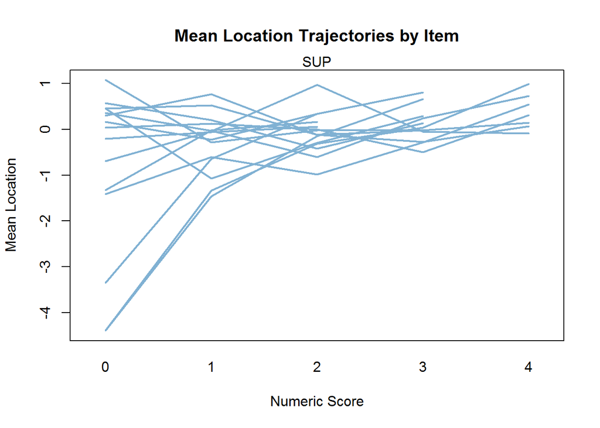

```
## $SUP
## $SUP$meanLocations
##     recodedScore0 recodedScore1 recodedScore2 recodedScore3 recodedScore4
## q4    -4.39521117   -1.46552545 -1.429935e-01    0.66277852            NA
## q5    -1.41577671   -0.60258855 -9.876806e-01   -0.27928132    0.54940575
## q6    -4.39521117   -1.33446293 -3.123233e-01    0.03980241    0.98884263
## q7    -3.34773296   -0.64260608  3.425231e-01    0.81043078           NaN
## q9    -0.68724944   -0.04045759  9.736790e-01   -0.05023639   -0.08703919
## q10    0.57573706    0.20619639 -4.149307e-01    0.13547748            NA
## q11    1.07679104   -0.28083982 -1.646801e-02   -0.02169795    0.14354087
## q22    0.29689549    0.76630242 -1.220693e-01   -0.01952038            NA
## q23    0.04232996    0.13009383 -8.572273e-05   -0.49680978    0.31159646
## q25    0.45600795    0.52237601 -1.186113e-01   -0.27540171    0.06881001
## q26    0.45600795   -1.07515931 -2.974486e-01    0.29125749           NaN
## q27   -0.20079101   -0.05471362  6.032588e-02            NA            NA
## q28    0.16239679   -0.22407912  3.405076e-01            NA            NA
## q30   -1.32737109   -0.01612610  1.683217e-01           NaN           NaN
## q32    0.36346713   -0.02923437 -6.076305e-01    0.24028574    0.73196722
##
## $SUP$sdLocations
##     recodedScore0 recodedScore1 recodedScore2 recodedScore3 recodedScore4
## q4             NA     1.2554953     0.6136562     0.9248912            NA
## q5      2.6222004     1.5225986            NA     0.7640833     0.9684247
## q6             NA     1.0721197     0.4310832     0.6008621     0.8168126
## q7      1.4813579     0.7434256     0.7319423     1.0464934            NA
## q9      0.8879086     1.4470021     0.5203989     1.3513384     0.4354433
## q10     0.6935187            NA     1.5566897     1.0144857            NA
## q11            NA     0.8827572     1.2398217     1.2095449     2.2712925
## q22     0.4564173     0.7565535     0.9885930     1.7798113            NA
## q23     0.1617420     0.9418578     1.3293400     1.9497071     0.6616609
## q25     0.3532869     1.2193389     1.4191423     0.8744940     1.5988142
## q26     0.3532869     2.2516171     1.1310056     1.0189503            NA
## q27     0.5755671     1.2778674     1.2854277            NA            NA
## q28     0.9781385     1.1938442     1.5581163            NA            NA
## q30     2.0961068     0.3775916     1.0650244            NA            NA
## q32     0.6080920     0.2664793     1.5025236     1.3214527     1.3830771
```

```r
mn.traj(SUPanalysis)
```

You can use `palette`, `writeout`, `imageType`, and `fileSuffix` as above.

Note that the graphic is only a *summary* of the mean trajectories. For your papers, look at the mean locations within each item in the table provided by this function or the one from `item.analysis()` (they should be identical).

# Other (base `R`) functions

## `cor(method = "pearson")`

### Use for calculating correlations with continuous external variables

This is a base `R` function that calculates correlation. You are welcome to use Excel or any other spreadsheet/stats program to calculate simple correlations between your estimated thetas and external variables.

```r
?cor

# Note that this code will only work if the respondents are in the same order in
#   your scores object and your vars object.

View(SUPvars)
# q3 is the number of years of teaching experience of the respondent

names(SUPanalysis)   # to see what stored results there are
```

```
##  [1] "itemPars"       "itemSEs"        "itemThres"      "itemFit"
##  [5] "persPars"       "persSEs"        "persRaw"        "persMax"
##  [9] "persFit"        "popDist"        "sepRel"         "estSummary"
## [13] "classicalStats" "empties"        "scoresOrig"     "scoresRecoded"
## [17] "itemInfo"       "consInfo"       "varsInfo"
```

```r
SUPanalysis$persPars # to view the person estimates
```

```
##         SUP_EAP
## 110  2.18985787
## 111  0.30525507
## 112 -0.10263505
## 113  1.30126651
## 114 -1.21394828
## 115 -2.07465423
## 116 -0.02256299
## 117  0.20619639
## 118 -0.61528113
## 119 -0.02166735
## 120  1.07679104
## 121  0.25087145
## 122  0.03799394
## 123 -0.47118342
```

[output cut: 24 more lines]

```r
cor(SUPvars$q3, SUPanalysis$persPars, use = "complete.obs")
```

```
##         SUP_EAP
## [1,] 0.03041553
```

```r
# "complete.obs" is necessary so that missing data is dropped
```

You can also use this for alternative forms analysis. Let’s pretend that the `results1` and `results2` analyses actually came from two separately admininistered forms. You can obtain the (unadjusted) correlation between the person estimates from each form using `cor()`.

```r
cor(results1$persPars, results2$persPars)
```

```
##           SUP_EAP
## SUP_EAP 0.8227316
```

## “DIF” (must be calculated externally)

- Run two separate analyses in `crasch`, one for each group. *Save the results separately (use `fileSuffix`)!*
- If you have polytomous items, you will have to manually “match” parameters.  
  You should only consider pairs of item parameters *that have the same meaning.*

```r
# I am going to run DIF for the groups I created based on subject taught:
#   Group 1: English-Language Arts & Social Studies
#   Group 2: everyone else
View(SUPvars)

# You can set up two entirely separate analyses by splitting up your scores file
#   manually (externally in Excel).
#   Alternatively, you can use R to figure out which rows go into each analysis
table(SUPvars$CORE) # make sure there are only TWO groups

group1 = which(SUPvars$CORE == "core")
group2 = which(SUPvars$CORE == "non-core")
  # These are vectors that have the row numbers for each group

group1analysis = craschR(scores = SUPscores[group1, ], itemInfo = SUPitem,
                         consInfo = SUPcons, varsInfo = SUPvars, writeout = FALSE)
group2analysis = craschR(scores = SUPscores[group2, ], itemInfo = SUPitem,
                         consInfo = SUPcons, varsInfo = SUPvars, writeout = FALSE)

# You may receive errors.  These are often due to sample size issues.

item.analysis(group1analysis, writeout = TRUE, fileSuffix = "_group1")
item.analysis(group2analysis, writeout = TRUE, fileSuffix = "_group2")
# Use the item.analysis files to determine which parameters you can include in
#   your DIF analysis.
```